# COVID-19 Data Analyzation and Prediction

## by Fan Li

## Investigation Overview

> With 168,019 confirmed cases and 6,610 deaths, 148 countries were affected (*by March 16th*) by the Coronavirus disease. This outbreak has gone way beyond what we expected. This pandemic caused WHO (World Health Organization) to raise the health emergency to its highest level along with many more countries' top emergency warnings. This project is targeted to briefly analyze the COVID-19 outbreak in the United States with some comparison against China (worst hit area) along with a rough prediction of the spreading trend.

## Dataset Overview

> Data set is operated by the Johns Hopkins University Center for Systems Science and Engineering (JHU CSSE). Also, Supported by ESRI Living Atlas Team and the Johns Hopkins University Applied Physics Lab (JHU APL). I extracted 2989 records cover information for two countries, 1715 records in China and 1274 records in the U.S.. Information is recorded from 2020 Jan 22nd until 2020 Mar 16th.

## Confirmed cases geographic distribution

> The plot shows the virus on record is between (-160, -65) in longitude and (20,65) in latitude. More specifically, there are two humps in the Longitude distribution plot, they reflect more cases on both coasts. Other the other hand, there is a significant high volume in the latitude plot which occurs around 40 to 45 latitude. This points to WA, Northern CA, OR and Northern east coast states around NY.

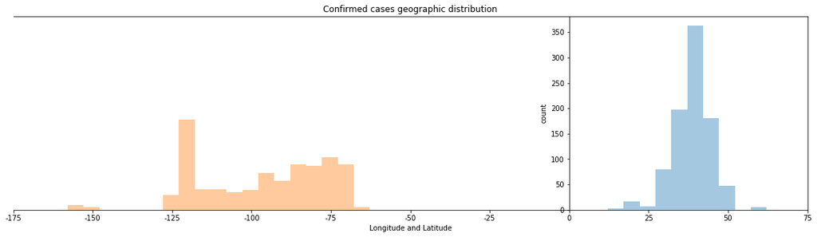

```python
## set bin edge
bin_edge = np.arange(usdf['Longitude'].min(),usdf['Latitude'].max()+5,5)
## plot
plt.figure(figsize =(20,5))
## set y axis to x= 0
plt.axes().spines['left'].set_position(('data',0))
sns.distplot(usdf['Latitude'],bins =bin_edge,kde =False)
sns.distplot(usdf['Longitude'], bins =bin_edge, kde= False)
## set xticks
tick = np.arange(-175,100, 25)
plt.xticks(tick,tick)
## set labels
plt.xlabel('Longitude and Latitude')
plt.ylabel('count')
plt.title('Confirmed cases geographic distribution');
```

## Accumulated numbers among states (up till Mar 16th)

> Northern east and Northern west states have the most cases reported. Top four significant states are WA, NY, CA and MA.

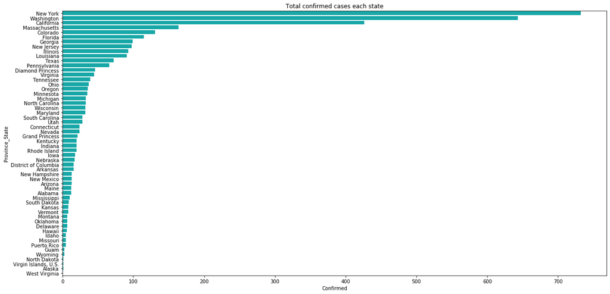

```python
statenum('Confirmed')
```

## Top 12 total deaths states VS Top 12 fatality rate states

> WA has the most dead cases while KS has the highest fatality rate on average.

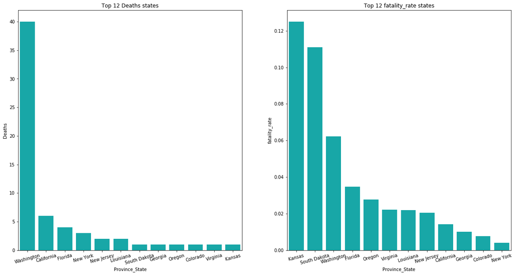

```python
statenum(deathcols)
```

## Top 12 total recoverys states VS Top 12 recovery rate states

> CA has the most recovered cases so far while AZ has the top recovery rate on average.

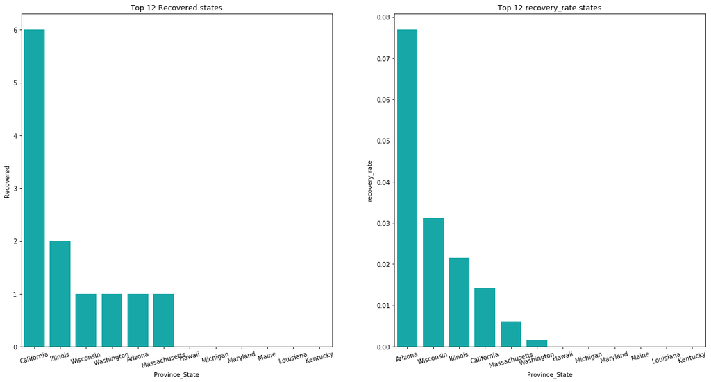

```python
statenum(recovercols)
```

## Accumulate confirmed cases along with time in China and U.S.

> Here we have a plot showing accumulate confirmed cases along with time between China and U.S.. There is a worrisome trend, from Jan 22nd the first COVID-19 case was observed in the U.S. it has been slowly spreading out unilt Fed 22nd a big population was infected and it started to spread out fast. Giving the same frame of time the virus is spreading faster in the U.S. than in China at this moment.

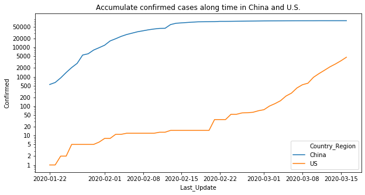

```python
## transform y scale to log10 in order
## to counter big population difference
plt.figure(figsize=(10,5))
plt.yscale('log')
sns.lineplot(data=countrydf, x ='Last_Update', y = 'Confirmed',hue= 'Country_Region' )
tick = [1,2,5,10,20,50,100,200,500,1000,2000,5000,10000,20000,50000]
plt.yticks(tick,tick)
plt.legend(loc =0)
plt.title('Accumulate confirmed cases along time in China and U.S.');
```

## Total Recovered and total Deaths between two countries

> Scatter plot show a relationship between total Recovered and total Deaths within two countries. Steeper slop indicates more people recovered than died. In this case, China shows a more comforting result.

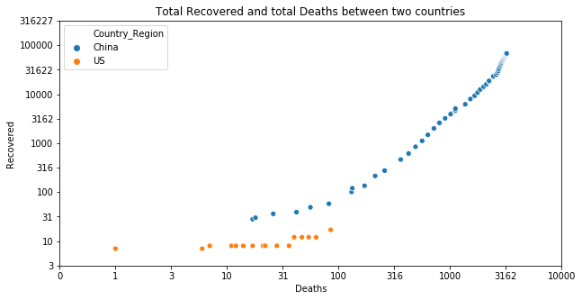

```python
plt.figure(figsize=(10,5))
## perform log transformation
sns.scatterplot(data= countrydf,y= countrydf['Recovered'].apply(logtrans),
                x =countrydf['Deaths'].apply(logtrans), hue= 'Country_Region')
## get x,t ticks locations and labels
xlocs, xlabels= plt.xticks()
ylocs, ylabels= plt.yticks()
## transform labels
xlabels = logtrans(xlocs, inverse= True).astype(int)
ylabels = logtrans(ylocs, inverse= True).astype(int)
plt.xticks(xlocs, xlabels)
plt.yticks(ylocs, ylabels)
plt.legend(loc= 0)
plt.title('Total Recovered and total Deaths between two countries');
```

## Average ratio comparisons

> Following plots compare average recovery rate as well as average fatality rate between two contries. Fortunately both countries showing a higher average recovery rate than average fatality rate. Red dots represent rates on Mar 15th respectively.

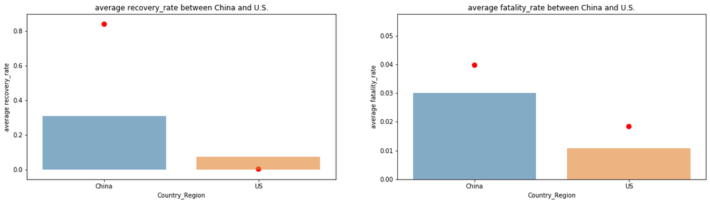

```python
indexes = [121, 122]
columnames =['recovery_rate','fatality_rate']
plt.figure(figsize=(20,5))
for index, columname in zip(indexes,columnames):
    plt.subplot(index)
    ## use red dot to indicate most recent rates
    sns.pointplot(data = uptodate, x = 'Country_Region', y= columname,color ='r',join =False,edgecolors="white")
    sns.barplot(data= countrydf, x= 'Country_Region', y= columname, ci= False, alpha = 0.6)
    plt.ylabel('average {}'.format(columname))
    plt.title('average {} between China and U.S.'.format(columname));
```

## Prediction

> Following is a prediction model using logistic growth algorithm. In the title, max infections represent predicted maximum total confirmed cases; r is the per capita rate of increase. The greater r is, the faster the rise to the peak. As the model shows, max confirmed cases would likely be around 37,774, and 15 days from Mar 16th which is Mar 31st, confirmed cases might reach over 30,000.

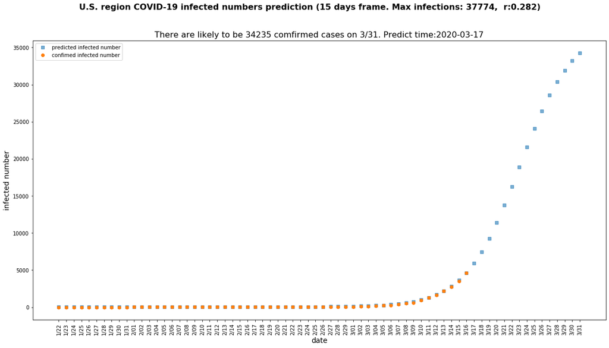

```python
## call function using 15 dayframe
predict(15)
```

> Limitation: This model has very limited perspective, since the dataset is not large enough to train the model at this point (represented by orange dots). The model does not yet take other elements into consideration, eg SEIR model, SIRS model, susceptible and infective mobility, medical break though and many more.

**This project is out of personal interest and it is for demonstration only, it should not be used for academical research nor clinical purpose.**